# Quality Improvement Stats

Vanessa Sochat

August 4, 2016

## Testing Impact of Clinical Intervention

We are testing the null hypothesis that an intervention, specifically, some procedural change for the clincian, had no effect on quality of care. Specifically, we are using correctness of discharge reports as a measure of this effect. A more correct report is indicative of an improvement in treatment.

#### Reading in Data

Let’s first read in our data.

```r
#install.packages('exactRankTests')
library(exactRankTests)
dm = read.csv("dm.csv")
head(dm)
```

```
##   pre_dm_points pre_dm_total_possible post_dm_points post_dm_possible
## 1             1                     5              5                5
## 2             5                     5              5                5
## 3             5                     5              5                5
## 4             5                     5              5                5
## 5             5                     5              5                5
## 6             5                     5              3                5
```

You’ll notice that I converted the .xls to a comma separated value (csv) file, and deleted the calculations that were done in Excel. We are going to do them here! Here is how we see our columns:

```r
colnames(dm)
```

```
## [1] "pre_dm_points"         "pre_dm_total_possible" "post_dm_points"
## [4] "post_dm_possible"
```

Let’s calculate a new column, the percentage (or score) for each timepoint.

```r
dm$pre_percentage = dm$pre_dm_points / dm$pre_dm_total_possible
dm$post_percentage = dm$post_dm_points / dm$post_dm_possible
head(dm)
```

```
##   pre_dm_points pre_dm_total_possible post_dm_points post_dm_possible
## 1             1                     5              5                5
## 2             5                     5              5                5
## 3             5                     5              5                5
## 4             5                     5              5                5
## 5             5                     5              5                5
## 6             5                     5              3                5
##   pre_percentage post_percentage
## 1            0.2             1.0
## 2            1.0             1.0
## 3            1.0             1.0
## 4            1.0             1.0
## 5            1.0             1.0
## 6            1.0             0.6
```

You can see that we get better precision than we did with Excel, “better” meaning more consistent with decimal places, etc.

#### Filtering out NA values

We want to compare the list of before percentages with after percentages to determine if they are significantly different, but some of our data has NA values! Let’s put those values into a variable, and remove the NAs as we do this:

```r
before = dm$pre_percentage[!is.na(dm$pre_percentage)]
after = dm$post_percentage[!is.na(dm$post_percentage)]
```

#### Distribution of the Scores and Choosing a Test

There are tests that you can do to determine if your data is normally distributed, but sometimes it is sufficient to just look at it. I can look at the numbers (my there are a lot of 1’s!) or the plots below to see that we definitely do not have normally distributed data:

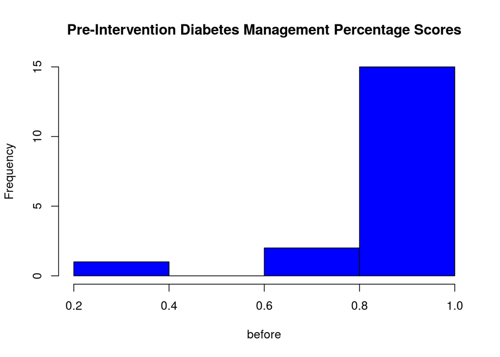

```r
hist(before,breaks=5,col="blue",main="Pre-Intervention Diabetes Management Percentage Scores")
```

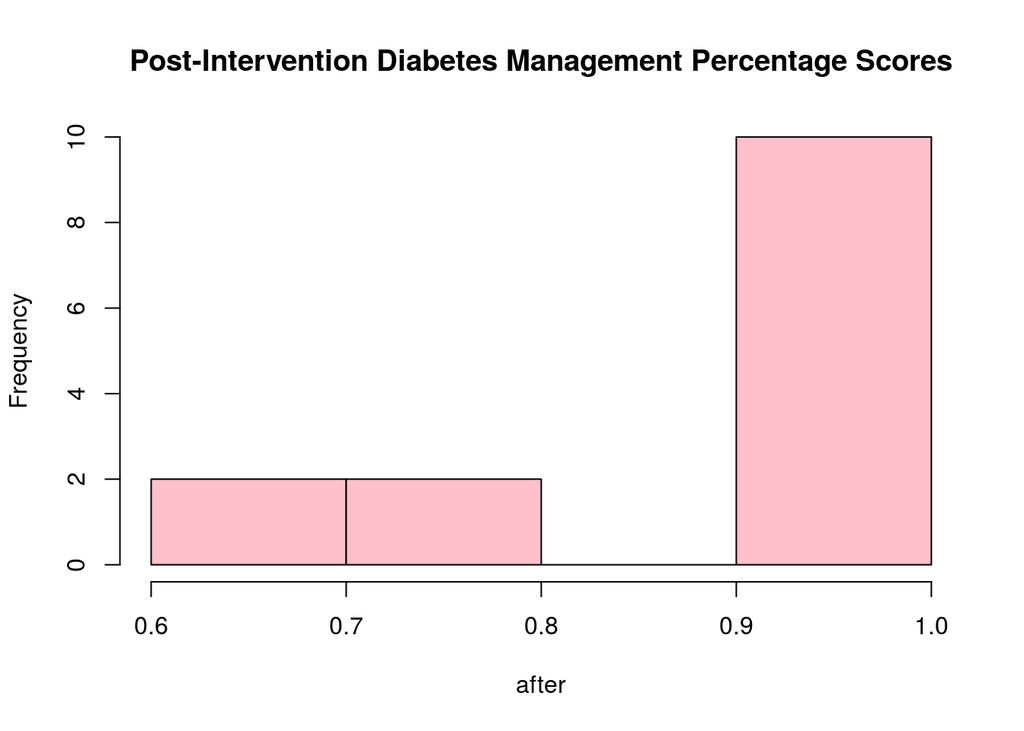

```r
hist(after,breaks=5,col="pink",main="Post-Intervention Diabetes Management Percentage Scores")
```

##### Performing the Test

We can now use a permutation test to assess for differences. This is two-sided:

```r
perm.test(before,after,alternative="two.sided",exact=TRUE)
```

```
##
##  2-sample Permutation Test (scores mapped into 1:(m+n) using
##  rounded scores)
##
## data:  before and after
## T = 528, p-value = 0.8626
## alternative hypothesis: true mu is not equal to 0
```

This shows us that the means are not significantly different.